# QOSF QC Mentorship Program - Task 1

#### Emlyn Graham

For my screening task, I chose to do the first task (see the [Google Doc](https://docs.google.com/document/d/1Ow3v8Y4rYBdgxXNxKV9ZUAM4bwL6211U6DWCcByZ4A4)). It seemed like a good chance to play with a QC framework and gates, given that my only exposure to QC is through quantum information theory (a course and a project) at university.

After playing around with the problem for a bit, I came to the following approach. This solution works through

- Part 1: Building the circuits
- Part 2: Optimising the circuits
- Part 3: Having a bit of fun

where I solve the problem as stated in Parts 1 and 2, and play with the parameters of the problem in Part 3.

## Part 1: Building the circuits

I chose Qiskit, for no particular reason. To start, we need to import the right things.

```python
import numpy as np
from scipy import optimize
from qiskit import QuantumCircuit, Aer, execute
import matplotlib.pyplot as plt
%matplotlib inline
np.random.seed(0)
```

In addition, we need to choose a simulator backend. For simplicity, I started with the `statevector_simulator`, which simulates circuits without measurement or noise (just the unadulterated quantum states).

```python
statevector_backend = Aer.get_backend('statevector_simulator')
```

To most easily solve this problem, I settled on making two classes: one for creating and storing the specific layered circuits in the task, and another to do the optimisation. Starting with the former, which I called `layered_circuit`, I coded up the following class:

```python
class layered_circuit():
    def __init__(self, angles):
        self.angles = angles
        self.L = np.size(self.angles)//8
        self.angles = np.reshape(angles, (self.L, 8))
        self.circuit = QuantumCircuit(4)
        for i in range(self.L):
            self.add_layer(self.angles[i])

    def add_odd(self, angles):
        #Add in the x rotations
        self.circuit.rx(angles[0],0)
        self.circuit.rx(angles[1],1)
        self.circuit.rx(angles[2],2)
        self.circuit.rx(angles[3],3)
        return None

    def add_even(self, angles):
        #Add in the z rotations
        self.circuit.rz(angles[0],0)
        self.circuit.rz(angles[1],1)
        self.circuit.rz(angles[2],2)
        self.circuit.rz(angles[3],3)
        #and then add the controlled phase gates
        self.circuit.cz(0,1)
        self.circuit.cz(0,2)
        self.circuit.cz(0,3)
        self.circuit.cz(1,2)
        self.circuit.cz(1,3)
        self.circuit.cz(2,3)
        return None

    def add_layer(self, angles):
        odd_angles = angles[:4]
        even_angles = angles[4:]
        self.add_odd(odd_angles)
        self.add_even(even_angles)
        return None
```

This class takes a flat array of angles, with eight needed per layer (as defined in the task). It helps to actually see what the circuit looks like, so using random inputs we can create and draw a couple using the inbuilt functionality of Qiskit:

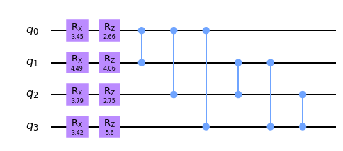

```python
single_layer_angles = 2*np.pi*np.random.rand(1,8).flatten()
single_layer_circuit = layered_circuit(single_layer_angles)
single_layer_circuit.circuit.draw('mpl')
```

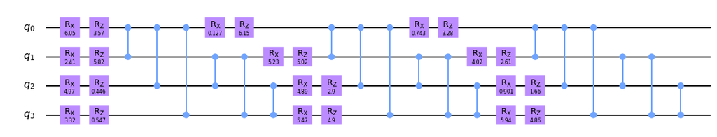

```python
layered_circuit(2*np.pi*np.random.rand(3,8).flatten()).circuit.draw('mpl')
```

Here we can see circuits with $L=1$ and $L=3$ respectively, with each angle randomly generated in the interval $(0,2\pi)$.

To solve this task, these angles need to be tuned to get the circuit to output a statevector as close as possible to a predetermined (random) statevector. To do this, we need optimisation!

# Part 2: Optimising the circuits

To do the required optimisation, I decided to create another class, `layered_circuit_optimiser`, that uses the previously made `layered_circuit`. It starts with randomly generated angles for the gates, which are restricted to the interval $(0,2\pi)$ as defined in the task guidelines. I decided on the *COBYLA* (Constrained Optimisation BY Linear Approximation) method for `scipy.optimize.minimize`, which doesn't require any information about the cost function derivatives. See the [scipy docs](https://docs.scipy.org/doc/scipy/reference/optimize.minimize-cobyla.html) page for more information.

```python
class layered_circuit_optimiser():
    def __init__(self, random_vector, L, backend, use_constraints=False, tol=10**(-4), maxiter=10000, verbose=True):
        self.L = L
        self.random_vector = random_vector
        # Can use this option to force the angles
        self.use_constraints = use_constraints
        if self.use_constraints == True:
            self.constraints = []
            for element in range(self.L*8):
                l = {'type': 'ineq',
                     'fun': lambda x, lb=0.0, i=element: x[i] - lb}
                u = {'type': 'ineq',
                     'fun': lambda x, ub=2*np.pi, i=element: ub - x[i]}
                self.constraints.append(l)
                self.constraints.append(u)
        self.tol = tol
        self.maxiter = maxiter
        self.backend = backend
        self.verbose = verbose

    def cost_function(self, angles):
        circuit = layered_circuit(angles)
        job = execute(circuit.circuit, self.backend)
        result = job.result()
        outputstate = result.get_statevector(circuit.circuit)
        return np.linalg.norm(outputstate-random_vector)

    def minimise(self):
        initial_angles = 2*np.pi*np.random.rand(self.L,8).flatten()
        if self.use_constraints == True:
            result = optimize.minimize(self.cost_function, initial_angles, method='COBYLA', constraints=self.constraints, tol=self.tol, options={'maxiter': self.maxiter, 'disp': False})
            if self.verbose:
                if result['success'] == False:
                    print("L =",self.L, result['message'])
            return result
        else:
            result = optimize.minimize(self.cost_function, initial_angles, method='COBYLA', tol=self.tol, options={'maxiter': self.maxiter, 'disp': False})
            if self.verbose:
                if result['success'] == False:
                    print("L =",self.L, result['message'])
            return result
```

As required in the task guidelines, we need to pick a random statevector to minimise against. Since there are 4 qubits, this statevector is of size 16, and needs to be normalised.

```python
random_vector = np.random.random(16) + np.random.random(16) * 1j
random_vector = random_vector/np.linalg.norm(random_vector)
```

> You will see that even this isn't enough for the algorithm to converge to within tolerance in many cases, but since I am doing on a very old laptop away from my main computer, I didn't want to wait around for too long.

```python
n_layers = 15
tolerance = 10**(-6)
maxiterations = 10000
```

```python
number_of_layers = []
minimised_cost_functions = []
```

```python
for L in range(n_layers+1):
    optimiser = layered_circuit_optimiser(random_vector, L, statevector_backend, use_constraints=True, tol=tolerance, maxiter=maxiterations)
    result = optimiser.minimise()
    number_of_layers.append(L)
    minimised_cost_functions.append(result['fun'])
```

```
L = 3 Maximum number of function evaluations has been exceeded.
L = 4 Maximum number of function evaluations has been exceeded.
L = 8 Maximum number of function evaluations has been exceeded.
L = 10 Maximum number of function evaluations has been exceeded.
L = 11 Maximum number of function evaluations has been exceeded.
L = 12 Maximum number of function evaluations has been exceeded.
L = 13 Maximum number of function evaluations has been exceeded.
```

[figure not shown]

```python
fig, ax = plt.subplots()
ax.scatter(number_of_layers, minimised_cost_functions)
ax.set_ylabel(r'$min_{\theta}\|\phi(\theta) - \varphi\|$')
ax.set_xlabel(r'$L$')
ax.set_title("Minimum cost function values with unconstrained parametric gate angles")
plt.show()
```

## Part 3: Having a bit of fun

### Removing the angular constraint

The first restriction in this problem that interested me was the range of angles, $(0, 2\pi)$, particularly given how difficult it is for the solver to minimise the cost function with this restriction. It is an odd restriction, given that the Bloch sphere (single qubit) has $4\pi$ symmetry, not $2\pi$. This can be demonstrated by taking some sets of input angles modulo $2\pi$ and $4\pi$, and comparing the cost functions, as shown below.

```python
test_angles = np.array([4.58720534,  5.12976832,  4.35786745,  6.0319927 ,  0.83087618,
        2.95726568,  1.35676681,  6.61611607,  1.47745495,  5.15871066,
        6.58166545,  4.43165288,  3.38237775, -0.35100602,  3.34341531,
        5.09094119,  4.70655196,  3.63604573,  0.36776149,  1.50521657,
        3.33197588,  5.50577004,  4.30233816,  3.28400418,  1.69197184,
        4.16878838,  5.49833625,  4.8553416 ,  5.21890076,  0.41695165,
        1.02446935,  2.19507073,  4.7542675 ,  2.68182992,  5.48189534,
        0.76287412,  6.33515418,  3.72404662,  2.41016765,  1.96144032])
base_circuit = layered_circuit(test_angles)
base_job = execute(base_circuit.circuit, statevector_backend)
mod2pi_circuit = layered_circuit(test_angles%(2*np.pi))
mod2pi_job = execute(mod2pi_circuit.circuit, statevector_backend)
mod4pi_circuit = layered_circuit(test_angles%(4*np.pi))
mod4pi_job = execute(mod4pi_circuit.circuit, statevector_backend)
print("Base cost function value: "
      , np.linalg.norm(base_job.result().get_statevector(base_circuit.circuit, decimals=6)-random_vector))
print('Modulo 2 pi: '
      , np.linalg.norm(mod2pi_job.result().get_statevector(mod2pi_circuit.circuit, decimals=6)-random_vector))
print("Modulo 4 pi: "
      , np.linalg.norm(mod4pi_job.result().get_statevector(mod4pi_circuit.circuit, decimals=6)-random_vector))
```

```
Base cost function value:  0.5472662324810892
Modulo 2 pi:  1.9236682850184839
Modulo 4 pi:  0.5472662324810891
```

Given that this is true, it's interesting to see whether we can get closer to the random vector by removing the constraints on the angles. We know that, whatever their final values, they are equivalent to some number in the interval $(0,4\pi)$. This is a quick change to make, and nets the following results:

```
L = 2 Maximum number of function evaluations has been exceeded.
L = 3 Maximum number of function evaluations has been exceeded.
L = 4 Maximum number of function evaluations has been exceeded.
L = 5 Maximum number of function evaluations has been exceeded.
L = 6 Maximum number of function evaluations has been exceeded.
L = 7 Maximum number of function evaluations has been exceeded.
L = 8 Maximum number of function evaluations has been exceeded.
L = 9 Maximum number of function evaluations has been exceeded.
L = 10 Maximum number of function evaluations has been exceeded.
L = 13 Maximum number of function evaluations has been exceeded.
```

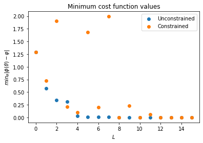

```python
minimised_cost_functions_unconstrained = []
for L in range(n_layers+1):
    optimiser = layered_circuit_optimiser(random_vector, L, statevector_backend, use_constraints=False, tol=tolerance, maxiter=maxiterations)
    result = optimiser.minimise()
    minimised_cost_functions_unconstrained.append(result['fun'])
fig, ax = plt.subplots()
ax.scatter(number_of_layers, minimised_cost_functions_unconstrained, label="Unconstrained")
ax.scatter(number_of_layers, minimised_cost_functions, label="Constrained")
ax.set_ylabel(r'$min_{\theta}\|\phi(\theta) - \varphi\|$')
ax.set_xlabel(r'$L$')
ax.set_title("Minimum cost function values")
ax.legend()
plt.show()
```

### Changing the random vector

Another point of interest is whether changing the random vector we are optimising to will change how close we are able to get. To do that, you can change the seed for the random numbers, and then re-run the optimisation, comparing the results to those we have already found.

```python
np.random.seed(15)
v2 = np.random.random(16) + np.random.random(16) * 1j
v2 = v2/np.linalg.norm(v2)
```

```python
minimised_cost_functions_v2 = []
minimised_cost_functions_unconstrained_v2 = []
for L in range(n_layers+1):
    optimiser = layered_circuit_optimiser(v2, L, statevector_backend, use_constraints=True, tol=tolerance, maxiter=maxiterations)
    result = optimiser.minimise()
    minimised_cost_functions_v2.append(result['fun'])
for L in range(n_layers+1):
    optimiser = layered_circuit_optimiser(v2, L, statevector_backend, use_constraints=False, tol=tolerance, maxiter=maxiterations)
    result = optimiser.minimise()
    minimised_cost_functions_unconstrained_v2.append(result['fun'])
```

```
L = 4 Maximum number of function evaluations has been exceeded.
L = 9 Maximum number of function evaluations has been exceeded.
L = 10 Maximum number of function evaluations has been exceeded.
L = 11 Maximum number of function evaluations has been exceeded.
L = 12 Maximum number of function evaluations has been exceeded.
L = 2 Maximum number of function evaluations has been exceeded.
L = 3 Maximum number of function evaluations has been exceeded.
L = 4 Maximum number of function evaluations has been exceeded.
L = 5 Maximum number of function evaluations has been exceeded.
L = 6 Maximum number of function evaluations has been exceeded.
L = 7 Maximum number of function evaluations has been exceeded.
L = 8 Maximum number of function evaluations has been exceeded.
L = 9 Maximum number of function evaluations has been exceeded.
L = 13 Maximum number of function evaluations has been exceeded.
```

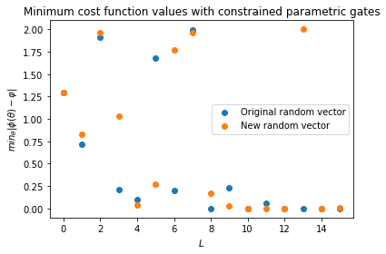

```python
fig, ax = plt.subplots()
ax.scatter(number_of_layers, minimised_cost_functions, label="Original random vector")
ax.scatter(number_of_layers, minimised_cost_functions_v2, label="New random vector")
ax.set_ylabel(r'$min_{\theta}\|\phi(\theta) - \varphi\|$')
ax.set_xlabel(r'$L$')
ax.set_title("Minimum cost function values with constrained parametric gates")
ax.legend()
plt.show()
```

Comparing the constrained gates, we can see that the general behaviour is similar, albeit with different values at specific $L$.

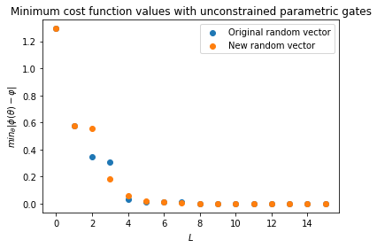

```python
fig, ax = plt.subplots()
ax.scatter(number_of_layers, minimised_cost_functions_unconstrained, label="Original random vector")
ax.scatter(number_of_layers, minimised_cost_functions_unconstrained_v2, label="New random vector")
ax.set_ylabel(r'$min_{\theta}\|\phi(\theta) - \varphi\|$')
ax.set_xlabel(r'$L$')
ax.set_title("Minimum cost function values with unconstrained parametric gates")
ax.legend()
plt.show()
```

Examining the unconstrained gates, we can see the behaviour is very similar, with only some variance around $L=2$ and $L=3$. To see more clearly what is happening at higher $L$, we can plot this on a $log$ scale.

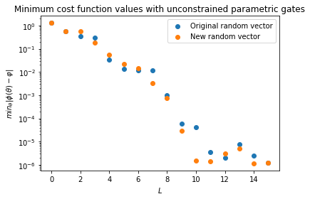

```python
fig, ax = plt.subplots()
ax.scatter(number_of_layers, minimised_cost_functions_unconstrained, label="Original random vector")
ax.scatter(number_of_layers, minimised_cost_functions_unconstrained_v2, label="New random vector")
ax.set_ylabel(r'$min_{\theta}\|\phi(\theta) - \varphi\|$')
ax.set_xlabel(r'$L$')
ax.set_title("Minimum cost function values with unconstrained parametric gates")
ax.set_yscale('log')
ax.legend()
plt.show()
```

This shows that the behaviour really is very similar, with the minimised cost function values quite close at each $L$. This gives us evidence that the exact vector being optimised to doesn't make a whole lot of difference to the performance of the minimisation.

## Conclusion and takeaways

Given this (decidedly limited) investigation, we have some indication that the more layers of $RX$/$RZ$/$CZ$ gates we have, the closer we can tune them to get a desired quantum statevector out at the end. Restricting the parameters these gates take somewhat impacts on this estimation ability, but the exact statevector being estimated doesn't make much of a difference.

Given some more time and computing power, I would look more into how this behaviour continues for higher $L$, and where (or if) it plateaus. I would also try to improve the rigour, by making sure each $L$ has converged sufficiently.

I am interested in how the results change with the order of the gates, and more generally with exactly which (parametric) gates are chosen. I would also be interested to see just how much impact measurement and noise have on the ability of an optimiser to replicate a given quantum statevector. I might play around in my spare time in the coming weeks!

> Note: *Thank you for giving up your time to read this work of mine. It's been a surprisingly fun exercise, and a great way to remove the rust off both my physics knowledge and coding ability (given I use neither in my day job)*